# Inferring miRNA activity in ENCODE RBP KD samples (with correction for shRNA off-target effects)

Gabrielle Perron

2026-September-24

# 1 Load libraries

```r
library(tidyverse)
library(scales)
```

# 2 Load the differential mRNA stability after correction for bias, batches, and shRNA off-target effects, 3’UTR nucleotide composition and length annotations, and miRNA seed matches

```r
stab_HepG2 <- read.csv(here("ENCODE_RBP_KD", "output", "supplementary_tables", "ENCODE_RBP_KD_stab_corr_bias_batch_shRNAoffTargetEffects_HepG2.csv"))
stab_K562 <- read.csv(here("ENCODE_RBP_KD", "output", "supplementary_tables", "ENCODE_RBP_KD_stab_corr_bias_batch_shRNAoffTargetEffects_K562.csv"))

UTR_nt <- read.table(here("data", "3UTR_nt_composition_new.txt"), header = TRUE, row.names = NULL)
UTR_length <- read.table(here("data", "3UTR_length_new.txt"), header = TRUE, row.names = NULL)
miRNAs_seed_matches <- read.csv(here("data", "miRNA_seed_matches_3UTRs2000bp.csv"), header = TRUE)
```

# 3 Prepare GLM data

Merge 3’UTR annotations with stability data for each cell line

```r
UTR <- merge(UTR_nt, UTR_length, by = 1)
UTR_miRNAs <- merge(UTR, miRNAs_seed_matches, by = 1)

glmMatrix_HepG2 <- merge(stab_HepG2, UTR_miRNAs, by = 1)
glmMatrix_K562 <- merge(stab_K562, UTR_miRNAs, by = 1)
```

# 4 Fit GLM models

Run GLM for each RBP KD sample, extracting coefficients and p-values

```r
fit_glm_sample <- function(glm_data, sample_name, cell_line) {
  # glm_data: complete data frame with response and all predictors
  # sample_name: name of the RBP KD sample
  # cell_line: "HepG2" or "K562"

  response_col <- which(colnames(glm_data) == sample_name)
  predictors_confounders_cols <- which(colnames(glm_data) != "X" & !grepl("ENCSR", colnames(glm_data)))

  # Formula: response ~ confounders and miRNA affinity predictors
  # Intercept included automatically
  formula_str <- paste0(
    colnames(glm_data)[response_col],
    " ~ ",
    paste(colnames(glm_data)[predictors_confounders_cols], collapse = " + ")
  )

  fit <- glm(as.formula(formula_str), data = glm_data, na.action = na.exclude)
  coef_summary <- coef(summary(fit))

  # Extract coefficients and p-values for predictors only (miRNA cols, skip intercept and confounders)
  predictor_rows <- which(grepl("^(miR\\.|let\\.)", rownames(coef_summary)))

  tibble(
    miRNA = rownames(coef_summary)[predictor_rows],
    coefficient = coef_summary[predictor_rows, 1],
    pvalue = coef_summary[predictor_rows, 4],
    sample_name = sample_name,
    cell_line = cell_line
  )
}

# Apply to all RBP KD samples in both cell lines
rbp_sample_names_HepG2 <- colnames(stab_HepG2)[-1]
rbp_sample_names_K562 <- colnames(stab_K562)[-1]

results_HepG2 <- map_df(rbp_sample_names_HepG2,
                         ~fit_glm_sample(glmMatrix_HepG2, .x, "HepG2"))
results_K562 <- map_df(rbp_sample_names_K562,
                        ~fit_glm_sample(glmMatrix_K562, .x, "K562"))

# Combine results from both cell lines
glm_results <- bind_rows(results_HepG2, results_K562) |>
  mutate(
    # Switch signs so coefficients represent miRNA activity (not target stability)
    coefficient = -coefficient,
    # Convert from ln to log2 scale
    coefficient_log2 = log2(exp(coefficient))
  )

head(glm_results)
```

```
## # A tibble: 6 × 6
##   miRNA     coefficient pvalue sample_name            cell_line coefficient_log2
##   <chr>           <dbl>  <dbl> <chr>                  <chr>                <dbl>
## 1 let.7         0.0107   0.207 ENCSR003LSA_SNRNP200_… HepG2              0.0154
## 2 miR.101       0.00309  0.704 ENCSR003LSA_SNRNP200_… HepG2              0.00446
## 3 miR.103a     -0.00110  0.873 ENCSR003LSA_SNRNP200_… HepG2             -0.00159
## 4 miR.10abc     0.00326  0.700 ENCSR003LSA_SNRNP200_… HepG2              0.00470
## 5 miR.122       0.00633  0.489 ENCSR003LSA_SNRNP200_… HepG2              0.00913
## 6 miR.124       0.00829  0.183 ENCSR003LSA_SNRNP200_… HepG2              0.0120
```

# 5 Multiple testing correction (separately for each cell line)

```r
glm_results <- glm_results |>
  group_by(cell_line) |>
  mutate(FDR = p.adjust(pvalue, method = "fdr")) |>
  ungroup()
```

# 6 Reformat miRNA names

```r
glm_results$miRNA <- gsub("\\.", "-", glm_results$miRNA)

# Define mapping from original names to canonical names
mirna_name_mapping <- tibble(
  original = c(
    "let-7", "miR-101", "miR-10abc", "miR-122", "miR-124", "miR-127", "miR-133abc",
    "miR-135ab", "miR-136", "miR-138", "miR-141", "miR-143", "miR-145", "miR-146ac",
    "miR-150", "miR-153", "miR-155", "miR-15abc", "miR-17", "miR-182", "miR-184",
    "miR-185", "miR-187", "miR-18ab", "miR-191", "miR-193", "miR-194", "miR-196abc",
    "miR-199ab-5p", "miR-19ab", "miR-1ab", "miR-200bc", "miR-203", "miR-204",
    "miR-21", "miR-210", "miR-214", "miR-216a", "miR-216b", "miR-217", "miR-218",
    "miR-22", "miR-221", "miR-23abc", "miR-24", "miR-25", "miR-26ab", "miR-27abc",
    "miR-299", "miR-29abcd", "miR-300", "miR-30abcdef", "miR-31", "miR-326",
    "miR-328a", "miR-329", "miR-338", "miR-33ab", "miR-34ac", "miR-370", "miR-375",
    "miR-376abd", "miR-376c", "miR-377", "miR-383", "miR-433", "miR-448",
    "miR-450a", "miR-487b", "miR-495", "miR-496", "miR-504", "miR-505", "miR-539",
    "miR-543", "miR-544", "miR-551a", "miR-7", "miR-758", "miR-874", "miR-9",
    "miR-93", "miR-96", "miR-99ab", "miR.181abcd"
  ),
  canonical = c(
    "let-7-5p", "miR-101-3p", "miR-10-5p", "miR-122-5p", "miR-124-3p", "miR-127-3p",
    "miR-133-3p", "miR-135-5p", "miR-136-5p", "miR-138-5p", "miR-141-3p", "miR-143-3p",
    "miR-145-5p", "miR-146-5p", "miR-150-5p", "miR-153-3p", "miR-155-5p", "miR-15-5p",
    "miR-17-5p", "miR-182-5p", "miR-184", "miR-185-5p", "miR-187-3p", "miR-18-5p",
    "miR-191-5p", "miR-193-3p", "miR-194-5p", "miR-196-5p", "miR-199-5p", "miR-19-3p",
    "miR-1-3p", "miR-200bc-3p", "miR-203a-3p", "miR-204-5p", "miR-21-5p", "miR-210-3p",
    "miR-214-3p", "miR-216a-5p", "miR-216b-5p", "miR-217", "miR-218-5p", "miR-22-3p",
    "miR-221-3p", "miR-23-3p", "miR-24-3p", "miR-25-3p", "miR-26-5p", "miR-27-3p",
    "miR-299-3p", "miR-29-3p", "miR-381-3p", "miR-30-5p", "miR-31-5p", "miR-326",
    "miR-328-3p", "miR-329-3p", "miR-338-3p", "miR-33-5p", "miR-34-5p", "miR-370-3p",
    "miR-375", "miR-376-3p", "miR-376c-3p", "miR-377-3p", "miR-383-5p", "miR-433-3p",
    "miR-448", "miR-450-5p", "miR-487-3p", "miR-495-3p", "miR-496", "miR-4725-5p",
    "miR-505-3p", "miR-539-5p", "miR-543", "miR-544a-3p", "miR-551-3p", "miR-7-5p",
    "miR-758-3p", "miR-874-3p", "miR-9-5p", "miR-302-3p", "miR-96-5p", "miR-99-5p",
    "miR-181-5p"
  )
)

glm_results <- glm_results |>
  left_join(mirna_name_mapping, by = c("miRNA" = "original")) |>
  mutate(miRNA = coalesce(canonical, miRNA)) |>
  select(-canonical)
```

# 7 Extract RBP name from sample names

```r
glm_results$RBP <- str_split_i(glm_results$sample_name, "_", 2)
```

# 8 Save results

```r
# Save all results in long-format tibble
write.csv(glm_results, file = here("ENCODE_RBP_KD", "output", "supplementary_tables", "ENCODE_RBP_KD_miRNA_activity.csv"), row.names = FALSE)
```

# 9 Load candidate RBP-miRNA interactions from miRNA activity inference before correction of mRNA stability estimates for shRNA off-target effects

```r
og_ints <- readRDS(here("ENCODE_RBP_KD", "output", "rds", "ENCODE_RBP_KD_initial_interactions.rds"))
colnames(og_ints) <- gsub("Type", "Type_og", colnames(og_ints))
```

# 10 Perform new FDR correction only the new P-values corresponding to original candidate RBP-miRNA interactions (from miRNA activity inference before correction of mRNA stability estimates for shRNA off-target effects), separately in each cell line

```r
dim(glm_results)
```

```
## [1] 124695      8
```

```r
dim(og_ints)
```

```
## [1] 68  4
```

```r
# Filter new miRNA activity results for original candidate miRNA-RBP interactions
new_res_og_ints <- og_ints |>
  inner_join(
    glm_results |>
      select(RBP, miRNA, cell_line, sample_name, coefficient, coefficient_log2, pvalue),
    by = c("RBP", "miRNA", "cell_line")
  )

dim(new_res_og_ints)
```

```
## [1] 132   8
```

```r
# Multiple testing correction separately by cell line
new_res_og_ints <- new_res_og_ints |>
  group_by(cell_line) |>
  mutate(FDR = p.adjust(pvalue, method = "fdr")) |>
  ungroup()
```

# 11 Filter for updated significant hits, and all their other replicates in the same cell line

```r
dim(new_res_og_ints)
```

```
## [1] 132   9
```

```r
new_sig_ints <- new_res_og_ints |>
  filter(FDR < 0.05) |>
  distinct(RBP, miRNA, cell_line)

new_ints_allReps <- new_res_og_ints |>
  semi_join(new_sig_ints, by = c("RBP", "miRNA", "cell_line"))

dim(new_ints_allReps)
```

```
## [1] 78  9
```

# 12 Retain only those where all replicates within the same cell line have coefficients in the same direction

```r
new_ints_allReps <- new_ints_allReps |>
  group_by(RBP, miRNA, cell_line) |>
  filter(n_distinct(sign(coefficient[coefficient != 0])) <= 1) |>
  mutate(
      # If miRNA activity is up when RBP is KD, it means that the RBP normally inhibits the miRNA
      # If miRNA activity is down when RBP is KD, it means that the RBP normally increases the activity of the miRNA
      Type = if_else(
      first(coefficient[coefficient != 0]) > 0,
      "-",
      "+"
    )
  ) |>
  ungroup()


dim(new_ints_allReps)
```

```
## [1] 78 10
```

# 13 Retain only those that are in the same direction (activating or inhibitory interactions) as the original hit

```r
new_ints_allReps <- new_ints_allReps |>
  group_by(RBP, miRNA, cell_line) |>
  filter(
    all(Type == first(Type_og))
  ) |>
  ungroup()
dim(new_ints_allReps)
```

```
## [1] 78 10
```

```r
new_ints <- unique(new_ints_allReps[, c("RBP","miRNA", "cell_line", "Type")])
dim(new_ints)
```

```
## [1] 39  4
```

```r
new_ints
```

```
## # A tibble: 39 × 4
##    RBP     miRNA       cell_line Type
##    <chr>   <chr>       <chr>     <chr>
##  1 AATF    miR-455-5p  HepG2     -
##  2 ABCF1   miR-33a-3p  HepG2     -
##  3 AKAP1   miR-370-3p  K562      -
##  4 BCCIP   miR-33-5p   HepG2     -
##  5 DDX55   miR-29-3p   HepG2     -
##  6 DKC1    miR-125a-3p HepG2     +
##  7 DKC1    miR-592     HepG2     -
##  8 DNAJC2  miR-21-5p   HepG2     -
##  9 EIF4B   miR-26-5p   HepG2     -
## 10 FAM120A miR-29-3p   HepG2     +
## # ℹ 29 more rows
```

```r
saveRDS(new_ints, here("ENCODE_RBP_KD", "output", "rds", "ENCODE_RBP_KD_interactions.rds"))
```

# 14 Prepare data for heatmap

```r
# Size and color limits
coeffs_lims <- 0.1
pvals_lims <- 10

# Helper function to create sample × miRNA matrices
make_matrix <- function(data, value_col) {
  data |>
    select(sample_name, miRNA, {{ value_col }}) |>
    pivot_wider(
      names_from = miRNA,
      values_from = {{ value_col }},
      values_fn = mean,
      values_fill = NA
    ) |>
    column_to_rownames("sample_name") |>
    as.matrix()
}

# Matrix of all coefficients
heatmap_all <- make_matrix(glm_results, coefficient)

# Matrix for display: interactions not retained after filtering are set to zero
significant_pairs <- new_ints |>
  distinct(RBP, miRNA)

heatmap_display <- glm_results |>
  left_join(
    significant_pairs |> mutate(significant = TRUE),
    by = c("RBP", "miRNA")
  ) |>
  mutate(
    coefficient = if_else(is.na(significant), 0, coefficient)
  ) |>
  select(sample_name, miRNA, coefficient) |>
  pivot_wider(
    names_from = miRNA,
    values_from = coefficient,
    values_fn = mean,
    values_fill = 0
  ) |>
  column_to_rownames("sample_name") |>
  as.matrix()

# Remove samples and miRNAs with no retained interactions
keep_rows <- rowSums(heatmap_display, na.rm = TRUE) != 0
keep_cols <- colSums(heatmap_display, na.rm = TRUE) != 0

heatmap_display <- heatmap_display[keep_rows, keep_cols]
heatmap_all <- heatmap_all[rownames(heatmap_display), colnames(heatmap_display)]

# Matrix of signed log10 p-values for clustering
signed_log_pval_matrix <- glm_results |>
  mutate(
    signed_log10_pval = abs(log10(pvalue)) * sign(coefficient)
  ) |>
  make_matrix(signed_log10_pval)

signed_log_pval_matrix <- signed_log_pval_matrix[
  rownames(heatmap_display),
  colnames(heatmap_display)
]

# Cluster samples using signed log10 p-values
dist_matrix <- as.dist((1 - cor(t(signed_log_pval_matrix))) / 2)
hc <- hclust(dist_matrix, method = "complete")

# Reorder rows by clustering
dat_clustered <- heatmap_all[rev(hc$order), ]

# Sort columns by row of maximum absolute coefficient
col_max_row <- apply(abs(dat_clustered), 2, which.max)
dat_sorted <- dat_clustered[, order(col_max_row)]

# Prepare plotting data
plot_data <- glm_results |>
  filter(
    !is.na(miRNA),
    sample_name %in% rownames(dat_sorted),
    miRNA %in% colnames(dat_sorted)
  ) |>
  mutate(
    # Point size represents absolute effect size while colour represents direction
    coefficient_log2 = pmin(abs(coefficient_log2), coeffs_lims),
    signed_log10_pval = pmax(
      pmin(abs(log10(pvalue)) * sign(coefficient), pvals_lims),
      -pvals_lims
    ),
    sample_name = factor(sample_name, levels = rownames(dat_sorted)),
    miRNA = factor(miRNA, levels = colnames(dat_sorted))
  )
```

# 15 Create heatmap

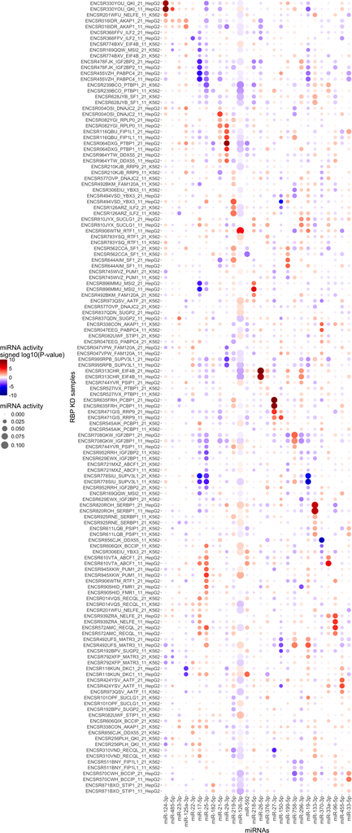

```r
p <- ggplot(plot_data) +
  geom_point(aes(
    x = miRNA,
    y = fct_rev(sample_name),
    size = coefficient_log2,
    fill = signed_log10_pval
  ),
  shape = 21,
  color = "transparent") +
  scale_size("miRNA activity", range = c(0.5, 10), breaks = seq(0, coeffs_lims, 0.025), limits = c(0, coeffs_lims), guide = guide_legend(override.aes = list(fill = "grey50"))) +
  scale_fill_gradientn(
    name = "miRNA activity\nsigned log10(P-value)",
    colours = c("darkblue", "blue", "white", "red", "darkred"),
    breaks = c(-10, -5, 0, 5, 10),
    limits = c(-pvals_lims, pvals_lims),
    oob = scales::squish
  ) +
  labs(x = "miRNAs", y = "RBP KD samples") +
  theme(
    legend.key.size = unit(1.5, "lines"),
    text = element_text(size = 20),
    axis.text = element_text(size = 14),
    axis.text.x = element_text(angle = 90, size = 16, vjust = 0.5, hjust = 1),
    legend.position = "left",
    panel.background = element_rect(fill = "white", colour = "white")
  )
p
```

```r
pdf(here("ENCODE_RBP_KD", "output", "figures",
         "ENCODE_RBP_KD_interactions_heatmap_allRepsAndCellsOfcandidates.pdf"),
    width = 15, height = 35)
p
dev.off()
```

```r
length(unique(plot_data$miRNA))
```

```
## [1] 28
```

```r
length(unique(plot_data$RBP))
```

```
## [1] 34
```

```r
length(unique(plot_data$sample_name))
```

```
## [1] 136
```